# Community Contribution QQPlot and Quantiles

# 5. What is type 9 and why is it used?

The default type being used for QQPlots (and a lot of other quantile functions in R such as ppoints) is type 9 (both in base R’s qqnorm and ggplot’s geom_qq).

Blom argues that for an underlying Normal distribution and based on somewhat general constraints $E[X(i)]$ is best approximated with $a=3/8$ as an offset. Upon reading that paper, the choice is actually pretty ad-hoc based on just a few numerical answers for small sample size (back then it was presumably quite hard to do numerical studies). There are some general arguments (using the essentially the mean value theorem), but they do not very tightly constrain $a$. Nonetheless, that choice of $a=3/8$ has persisted and is nowadays standard in QQPlots and even other quantile estimates (such as ppoints).

Since QQPlots are most often used to compare with Normal distributions, is is sensible to chose whichever quantile estimator works best for it. Nonetheless, if one wants to be careful, one should adjust the quantile estimates for QQPlots where we are not comparing against the normal distribution. For example, a similar strategy as in **Blom 1958** was later used in [Cunnane 1978](https://www.sciencedirect.com/science/article/abs/pii/0022169478900173) for other distributions, where the author identifies different offsets $a$ based on the underlying distribution.

We explicitly investigate which type was used for the various relevant base R and ggplot functions, and our findings (with references) are:

- [**Ggplot2 qq_geom source code**](https://github.com/tidyverse/ggplot2/blob/5a61e2e656d61469e5ae7e2ffa29fd755d9c1b71/R/stat-qq.R): In line 96, we see that the quantiles in ggplot’s QQ-plot are chosen from the ppoints function (whose default type is 9).
- Description of [**ppoint**](https://www.rdocumentation.org/packages/stats/versions/3.6.2/topics/ppoints) function. This is effectively a simplified version of the type selection, by providing an option to change the offset in $i−an+1−2a$ (this of course does not allow for specifying locally constant functions such as types 1,2 and 3). We can also explicitly compare:

```r
ppoints(5) - (1:5 - 3/8) / (5+1/4)
```

```
[1] 0 0 0 0 0
```

- Description of the base R [**quantile**](https://stat.ethz.ch/R-manual/R-devel/library/stats/html/quantile.html) function and a short description of the types based on the Hyndman-Fan paper. Base R quantile actually uses by default type 7, i.e. $pk=k−1n−1$:

```r
head(quantile(data, probs=probs,type=7)-quantile(data, probs=probs),5)
```

```
1% 2% 3% 4% 5%
 0  0  0  0  0
```

- Base R [**qqnorm**](https://stat.ethz.ch/R-manual/R-devel/library/stats/html/qqnorm.html) description; for qqline we can pick quantile type as well as the quantiles through which the line is drawn, however, qqnorm uses by default type 9 and – as far as I know – we cannot simply change to a different type. QQline also uses by default type 7. This is actually quite confusing in my opinion.

## 5.1 Back to our (now coinciding) original plots

Compare the (now less) naive plots with type 9 quantile choice vs base R/ggplot’s versions and we find precise agreement.

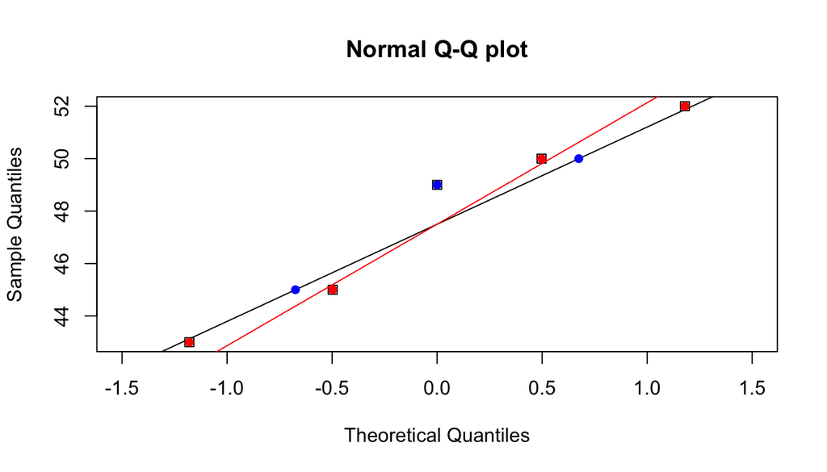

```r
n <- length(sorted_data)
probabilities <- (1:n - 3/8) / (n+1/4)
probabilities1 <- (1:n - 1) / (n-1)

theoretical_quantiles <- qnorm(probabilities)
theoretical_quantiles1 <- qnorm(probabilities1)

qqnorm(y,
       axes = TRUE,
       xlim = c(-1.5,1.5),
       frame.plot = TRUE,
       main = "Normal Q-Q plot",
       xlab = "Theoretical Quantiles",
       ylab = "Sample Quantiles",
       pch=0)
qqline(y, col = "black")
qqline(y, col = "red", qtype=9)
points(theoretical_quantiles, sorted_data, col = "red", pch = 16)
points(theoretical_quantiles1, sorted_data, col = "blue", pch = 16)
```

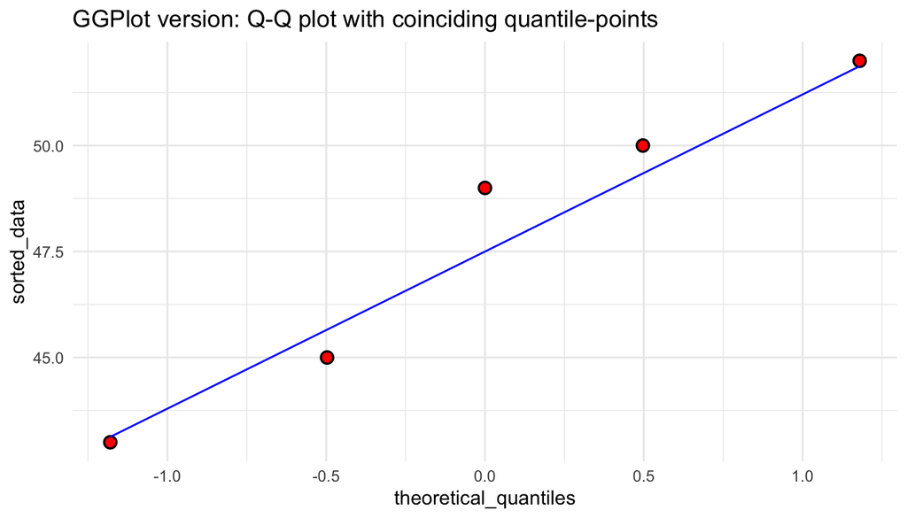

```r
n <- length(sorted_data)
probabilities <- (1:n - 3/8) / (n+1/4)
#probabilities <- (1:n - 1/3) / (n+1/3) # other choices are not precisely coinciding
theoretical_quantiles <- qnorm(probabilities)
naive <- data.frame(theoretical_quantiles,sorted_data)
ggplot() +
  geom_qq(data = head(age_gaps, 5), aes(sample = age_difference), shape = 1, color = "black", size = 2.2, stroke = 1.2) +
  geom_qq_line(data = head(age_gaps, 5), aes(sample = age_difference),color = "blue",line.p = c(.25, .75)) +
  geom_point(data = naive, aes(x = theoretical_quantiles, y = sorted_data), color = "red", size = 2) +
  ggtitle("GGPlot version: Q-Q plot with coinciding quantile-points") +
  theme_minimal()
```

# References and some remarks:

- [**Blom 1958:**](https://gwern.net/doc/statistics/order/1958-blom-orderstatistics.pdf) Original paper discovering the 9th quantile type, i.e., $i−3/8n+1/4$, and providing arguments about its efficacy (unbiased) for an underlying Normal distribution.
- [**Hyndman and Fan, 1996:**](https://www.amherst.edu/media/view/129116/original/Sample+Quantiles.pdf) Original paper outlining the 9 types of quantile estimators used in packages (at the time and still today).
- [**Ggplot2 qq_line source code**](https://github.com/tidyverse/ggplot2/blob/HEAD/R/stat-qq-line.R): The QQ-line is effectively generated in lines 78ff and we see that by default it is simply a line through the 25% and 75% sample quantile of the data.
- [**Ggplot2 qq_geom source code**](https://github.com/tidyverse/ggplot2/blob/5a61e2e656d61469e5ae7e2ffa29fd755d9c1b71/R/stat-qq.R): In line 96, we see that the quantiles in ggplot’s QQ-plot are chosen from the ppoints function (whose default type is 9).
- Description of [**ppoint**](https://www.rdocumentation.org/packages/stats/versions/3.6.2/topics/ppoints) function. This is effectively a simplified version of the type selection, by providing an option to change the offset in $i−an+1−2a$ (this of course does not allow for specifying locally constant functions such as types 1,2 and 3).
- Base R [**quantile**](https://stat.ethz.ch/R-manual/R-devel/library/stats/html/quantile.html) functions and a short description of the types based on the Hyndman-Fan paper.
- Base R [**qqnorm**](https://stat.ethz.ch/R-manual/R-devel/library/stats/html/qqnorm.html) description; for qqline we can pick type and the quantiles through which the line is drawn, however, qqnorm uses by default type 9 and as far as I know, we cannot change to a different type.

# Appendix A. Different choices of sample quantiles

Here, we briefly detail the different choices of lines we can draw in ggplot geom_qq_line, and clearly show that they’re chosen such that they run through the respective (chosen) quantiles. This is confirmed by looking at the [**Ggplot2 qq_line source code**](https://github.com/tidyverse/ggplot2/blob/HEAD/R/stat-qq-line.R).

(A similar plot and inspiration can be found in https://stackoverflow.com/questions/12766253/qqline-connects-the-first-and-third-quartiles-how-do-i-draw-a-line-between-diff)

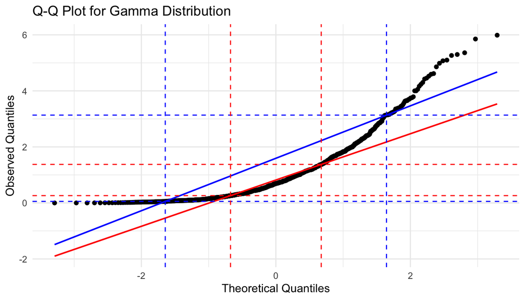

```r
set.seed(101)
z <- rgamma(1000, shape = 1)

# Calculate quantiles for reference lines
quantiles <- c(0.25, 0.75)
newprobs <- c(0.05, 0.95)
quantile_values <- quantile(z, probs = quantiles)
newprobs_values <- quantile(z, probs = newprobs)
theoretical_quantiles <- qnorm(c(quantiles, newprobs))

# Create the Q-Q plot using ggplot
p <- ggplot(data.frame(sample = z), aes(sample = sample)) +
  geom_qq() +
  geom_qq_line(color = "red", size = .7) + # line.p = c(0.25,0.75)
  geom_qq_line(color = "blue", size = .7, line.p = c(0.05,0.95)) +
  geom_hline(yintercept = quantile_values, color = "red", linetype = "dashed") +
  geom_hline(yintercept = newprobs_values, color = "blue", linetype = "dashed") +
  geom_vline(xintercept = theoretical_quantiles, color = c(rep("red", 2), rep("blue", 2)), linetype = "dashed") +
  ggtitle("Q-Q Plot for Gamma Distribution") +
  xlab("Theoretical Quantiles") +
  ylab("Observed Quantiles") +
  theme_minimal()

# Display the plot
print(p)
```

# Appendix B. Angles of QQ-plots

Here, we provide a bit more details about the slope of the QQ-Plots in general.

1. The slope of the QQPlot vs the standard normal is given in terms of the standard deviation of the distribution, i.e., larger slope = larger standard deviation and vice versa.
2. The intercept of the QQ-line is given in terms of the mean of the distribution.

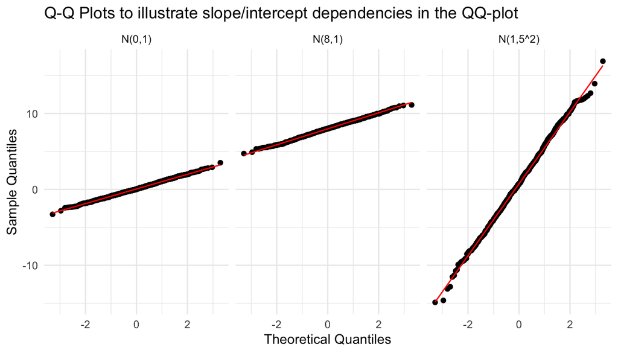

```r
set.seed(101)
w <- rnorm(1000,mean = 1, sd = 5)
v <- rnorm(1000,mean = 8, sd = 1)
r <- rnorm(1000,mean = 0, sd = 1)

newprobs <- c(0.1,0.9)
df <- data.frame(
  w = w,
  v = v,
  r = r
)

custom_labels <- c(
  w = "N(1,5^2)",
  v = "N(8,1)",
  r = "N(0,1)"
)

df_long <- gather(df, key = "Variable", value = "Value")

p <- ggplot(df_long, aes(sample = Value)) +
  geom_qq() +
  geom_qq_line(color = "red") +
  facet_wrap(~ Variable, ncol = 3, labeller = as_labeller(custom_labels)) +
  ggtitle("Q-Q Plots to illustrate slope/intercept dependencies in the QQ-plot") +
  xlab('Theoretical Quantiles') +
  ylab('Sample Quantiles') +
  theme_minimal()

# Display the plot
print(p)
```